# AboutAIC

tmyst

2019/12/23

### generalization error, empirical risk, and AIC

Generalization error: 予測分布$p$として$-E[log(p(x))]$,
$$-E[\log(p(x))] = \int{q(x)\log(p(x))}dx\\=\int{q(x)\log(q(x))dx + \int{q(x)\log(p(x)/q(x))dx} }$$
(1)Entropy, (2)Predicted distributionとActual distributionの距離の寄与に分割。ここで、すべてのxで$p(x) = q(x)$であれば第2項は0。

真の分布を仮定してダミーデータ作成

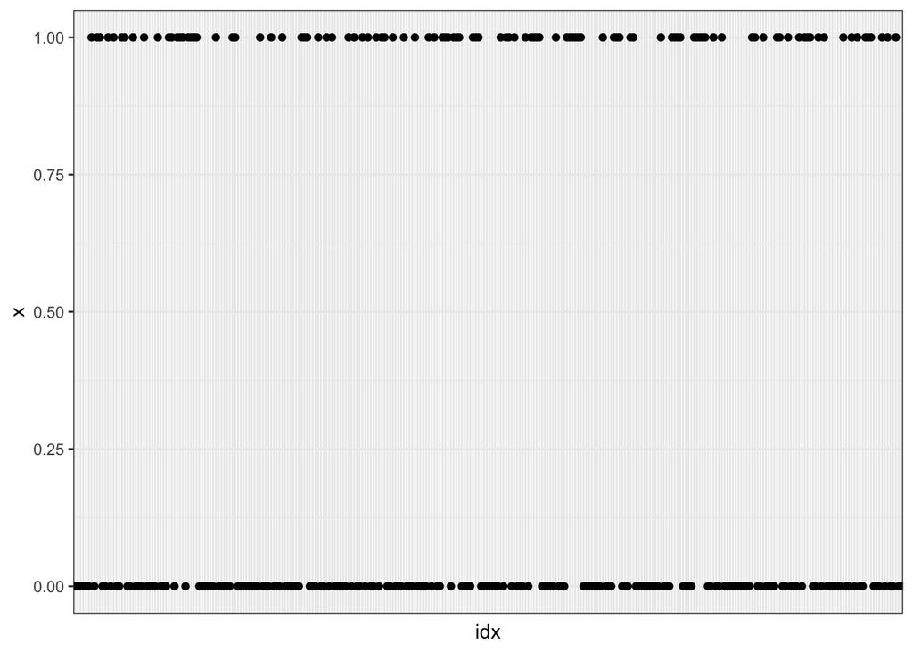

```r
set.seed(123)
q     <- 0.36
data_length <- 300
true_dist <- c(q, 1-q)
alpha <- 1
beta  <- 1
bern <- rbernoulli(p=q, n =data_length)
bern %>% as.integer() %>% data.frame(x = .) %>% rownames_to_column("idx") %>% ggplot(data = ., aes(x = idx, y = x)) +
  geom_point() + theme_bw() + theme(
  axis.line.x = element_blank(),
  axis.text.x = element_blank(),
  axis.ticks.x =element_blank()
)
```

#### Generalization Error

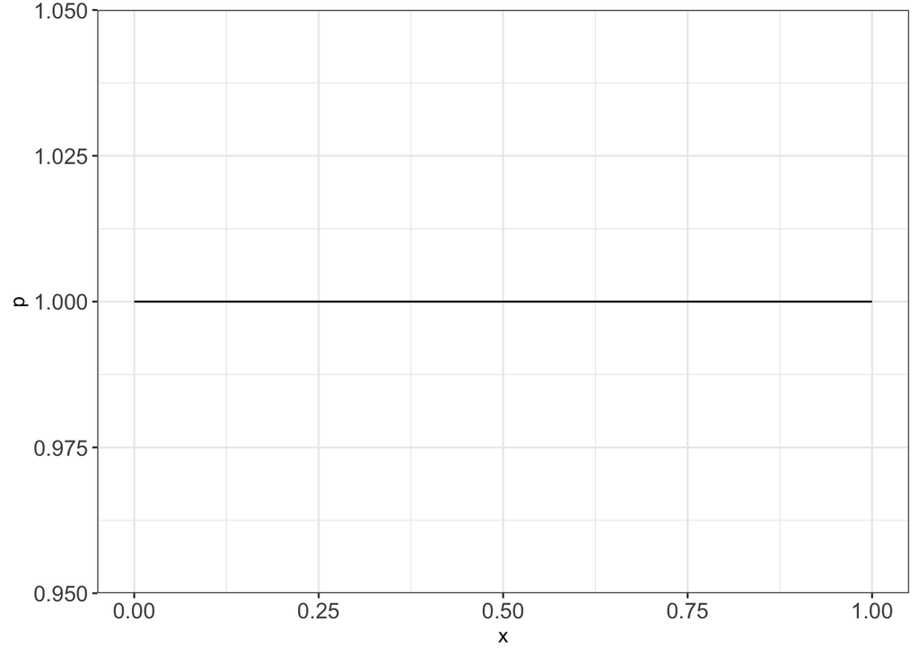

```r
data.frame(x = seq(0, 1, 0.1), p= dbeta(x = seq(0, 1, 0.1), alpha, beta)) %>% ggplot(data =., aes(x = x, y = p)) + geom_line() + theme_bw() +
  theme(axis.text.x = element_text(size = 12), axis.text.y = element_text(size = 12))
```

Maximum likelihoodにおいてはbernoulli分布のparameterのestimated valueはmeanであり$p_{m}(X) = \bar{x}^{X}(1-\bar{x})^{(1-\bar{X})}$となる。

```r
ml_pred_dist <- function(new_x, exp_data){
  pm <- sum(exp_data)/length(exp_data)
  pm^(new_x) * (1 - pm)^(1 - new_x)
}
ml_pred_dist(c(1,0), bern)
```

```
## [1] 0.3566667 0.6433333
```

Maximum likelihood estimationの場合のGeneralation loss : Mean expected log likelihoodの符号を逆転したものに等しい。
$$G_{n} = - E_{X}[\log{p^{\ast}(x)}] = -E_{X}[\log{p(x|\theta_{ML}})] = -\int{q(x)\log{p(x|\theta_{ML})}dx}$$
となる。今回は真の分布がわかっているため、この値は

```r
expected_log_lik <- function(base_dist, exp_data){
  pred_dist <- ml_pred_dist(c(1, 0), exp_data)
  sum( base_dist * log( pred_dist ) )
}
mean_log_loss <- function(base_dist, exp_data){
  -expected_log_lik(base_dist, exp_data)
}
gn <- mean_log_loss(true_dist, bern)
gn
```

```
## [1] 0.6534424
```

真の分布がわからないときにEmpirical lossからGeneralization lossを求める。
$$T_{n}=-\frac{1}{n}\sum{\log{p^{\ast}(x_{i})}}$$

```r
trained_loss <- function(exp_data){
  - sum(log(ml_pred_dist(new_x = exp_data, exp_data = exp_data))) / length(exp_data)
}
tn <- trained_loss(bern)
tn
```

```
## [1] 0.6514762
```

$$Bias = G_{n} - T_{n} = - \int{q(x)\log{p(x|\theta_{ML})}dx} + \frac{1}{n}\sum{\log{p^{\ast}(x_{i})}}$$
one time

```r
gn - tn
```

```
## [1] 0.001966205
```

```r
one_time_bias <- function(true_dist, exp_data){
  meanLogLoss <- mean_log_loss(true_dist, ml_pred_dist(c(1, 0), exp_data) )
  trainedLoss <- trained_loss(exp_data)
  meanLogLoss - trainedLoss
}
one_time_bias(true_dist = true_dist, exp_data = bern)
```

```
## [1] 0.04167101
```

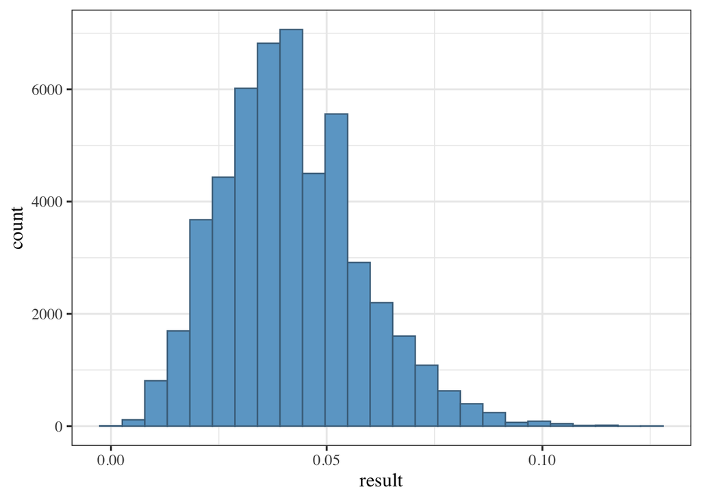

```r
res <- lapply(1:50000, function(i){
  sim_data <- rbinom(size = 1, n = data_length, prob = q)
  c(i, one_time_bias(true_dist = true_dist, exp_data = sim_data))
}) %>% do.call(rbind, .) %>% data.frame() %>% setNames(nm = c("index", "result"))

res %>% ggplot(data=.) +
  geom_histogram(aes(x=result), bins = 25, color = "skyblue4", fill = "skyblue3") +
  theme_bw(base_size = 14, base_family = "Times")
```

```r
(res$result %>% mean )
```

```
## [1] 0.04149235
```

```r
1 / length(bern)
```

```
## [1] 0.003333333
```

```r
my_aic <- function(exp_data, n_param){
  trained_loss(exp_data) + (n_param / length(exp_data) )
}
data.frame(my_aic = my_aic(bern, 1), tn_plus_bias = tn + 0.0033)
```

```
##      my_aic tn_plus_bias
## 1 0.6548095    0.6547762
```

```r
bern_model <- glm(bern ~ 1, family = binomial(link = "logit"))
(bern_model$aic)/( 2*length(bern) )
```

```
## [1] 0.6548095
```

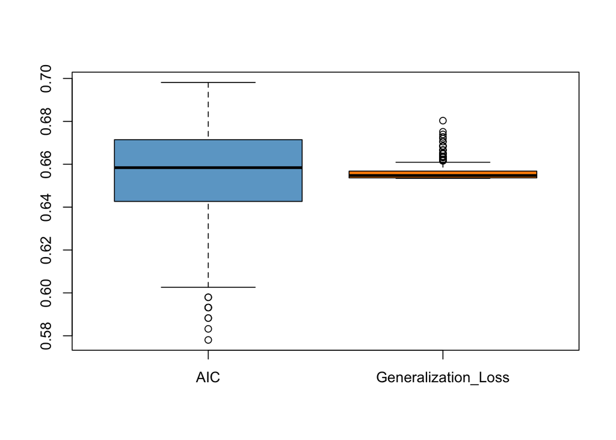

```r
a <- lapply(1:1000, function(i) {
  c(i, my_aic(rbinom(n = 200, size = 1, prob = q), 1))
  }) %>% do.call(rbind, .) %>% data.frame() %>% setNames(nm=c("ind", "res"))

b <- lapply(1:1000, function(i){
  exp_data <-  rbinom(n = 200, size = 1, prob = q)
  c(i, mean_log_loss(base_dist = true_dist, exp_data ))
  })%>% do.call(rbind, .) %>% data.frame() %>% setNames(nm=c("ind", "res"))

boxplot(a$res, b$res, names = c("AIC", "Generalization_Loss"), col = c("skyblue3", "darkorange"))
```

```r
data.frame(aic = a$res, gl = b$res) %>% summarise_all(mean)
```

```
##         aic        gl
## 1 0.6557202 0.6558527
```

### bayesian estimation

The conjugate prior distribution of bernoulli distribution is beta distribution. If the prior distribution is expressed as $\mathrm{Beta}(\alpha, \beta)$, then the posterior will be $\mathrm{Beta}(\alpha + \sum{x_{i}}, \beta + n - \sum{x_{i}})$.

Note: from bayes theorem:
$$p(\theta|X^{n})p(X^{n}) = p(X^{n}|\theta)\psi(\theta)$$
$$p(\theta|X^{n}) = \frac{p(X^{n}|\theta)\psi(\theta)}{\int{p(X^{n}|\theta)\psi(\theta)d\theta}} = \frac{q^{\alpha + \sum{x_{i}}-1}(1-q)^{\beta+n-\sum{x_{i}}-1}}{\mathrm{Beta(\alpha + \sum{x_{i}}, \beta + n - \sum{x_{i}})}}$$

If we plot the pior and posterior distributions,

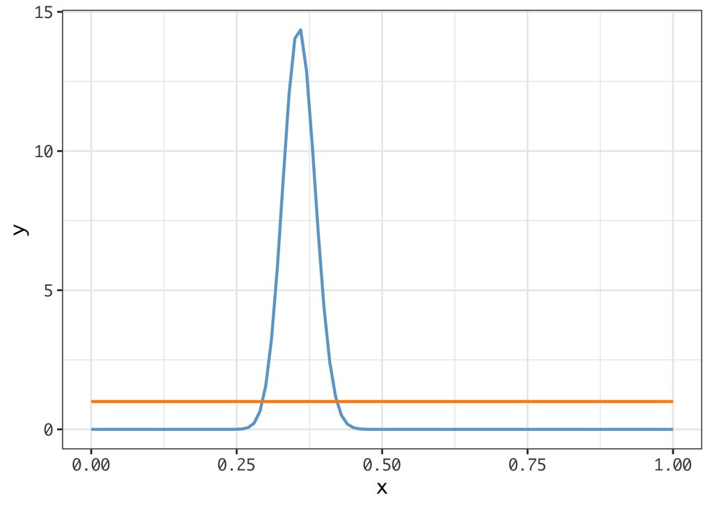

```r
beta_dist_prior <- data.frame(x = seq(0, 1, 0.01), y = dbeta(x = seq(0, 1, 0.01), shape1 = alpha, shape2 = beta))

alpha_post <- alpha + sum(bern)
beta_post <- beta + length(bern) - sum(bern)

beta_dist_post <- data.frame(x = seq(0, 1, 0.01), y = dbeta( x= seq(0, 1, 0.01), shape1 = alpha_post, shape2 = beta_post))

ggplot() +
  geom_line(data = beta_dist_post, aes(x = x, y = y), color = "skyblue3", size = 1) +
  geom_line(data = beta_dist_prior, aes(x = x, y = y), color = "darkorange", size = 1) +
  theme_bw(base_size = 14, base_family = "Monaco")
```

### Generalization loss:

Predicted distribution by bayesian estimation:
$$p^{\ast}(X) = E_{\theta}[p(X|\theta)] = \int{p(\theta|X^{n})p(X|\theta)d\theta}$$
For beta distribution:
$$p^{\ast}(X) = E_{\theta}[p(X|\theta)] = \int^{1}_{0}{p(X|\theta)p(\theta|X^{n})d\theta} = {(\frac{\alpha + \sum{x_{i}}}{\alpha + \beta + n})^{X}(\frac{\beta + n - \sum{x_{i}}}{\alpha + \beta + n})^{1-X}}$$

```r
ba_pred_dist <- function(new_x, exp_data, alpha, beta){
  new_alpha <- alpha + sum(exp_data)
  new_beta  <- beta + length(exp_data) - sum(exp_data)
  new_bernoulli_param <- new_alpha / (new_alpha + new_beta)
  new_bernoulli_param^(new_x) * (1 - new_bernoulli_param)^(1 - new_x)
}
pred_dist_2 <- ba_pred_dist(c(1,0), bern, 1, 1)
pred_dist_2
```

```
## [1] 0.3576159 0.6423841
```

Generalization loss for known dist q:
$$G_{n} = -E_{X}[\log{p^{\ast}(X)}] = - E_{X}[\log{(E_{\theta}[p(X|\theta)])}] = - \int{ q(X)\log{\left( \int{p(X|\theta)p(\theta|x^n)}d\theta \right) dX}}$$
In this case, true distribution is $q(x) =0.36^{x}(1-0.36)^{1-x}, \space x\in\{0, 1\}$,
$$-q\log{ \left( \frac{\alpha + \sum{x_{i}}}{\alpha + \beta + n} \right) }-(1 - q)\log{\left( \frac{\beta + n - \sum{x_{i}}}{\alpha + \beta + n} \right) }$$

```r
ba_expected_log_lik <- function(base_dist, exp_data, alpha, beta){
  pred_dist <- ba_pred_dist(c(1, 0), exp_data, alpha, beta)
  sum(base_dist * log(pred_dist))
}
ba_mean_log_loss <- function(base_dist, exp_data, alpha, beta){
  - ba_expected_log_lik(base_dist, exp_data, alpha, beta)
}
gn2 <- ba_mean_log_loss(true_dist, bern, 1, 1)
gn2
```

```
## [1] 0.6534306
```

trained loss:
$$T_{n} = - \frac{1}{n}\sum_{i}\log{p^{\ast}(x_{i})} = - \frac{1}{n}\sum_{i}{\log{E_{\theta}[p(x_{i}|\theta)]}}$$
$$T_{n} = \frac{1}{n}\left\{ \sum{x_{i}}\log{ \left( \frac{\alpha +\sum{x_{i}}}{\alpha + \beta + n} \right)} - (n-\sum{x_{i}})\log{ \left( \frac{\beta +n - \sum{x_{i}}}{\alpha + \beta + n} \right)} \right\}$$

```r
ba_trained_loss <- function(exp_data, alpha, beta){
  - mean(log(ba_pred_dist(exp_data, exp_data, alpha, beta)))
}
tn2 <- ba_trained_loss(bern, 1, 1)
tn2
```

```
## [1] 0.6514781
```

```r
ba_mean_log_loss(true_dist, exp_data = bern, alpha = 1, beta = 1 ) -
  ba_trained_loss(exp_data = bern, alpha = 1, beta = 1)
```

```
## [1] 0.001952423
```

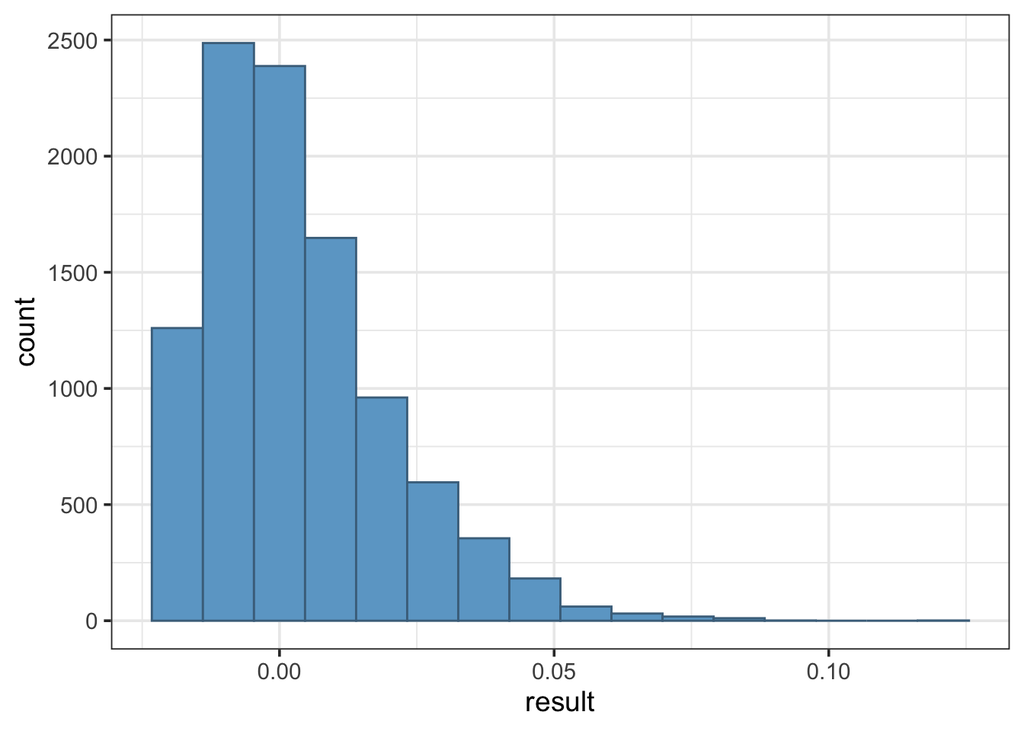

```r
ba_bias_res <- lapply(1:10000, function(i){
  new_x <- rbinom(n = data_length, size = 1, prob = q)
  c(i, ba_mean_log_loss(true_dist, new_x, alpha = 1, beta = 1) -
      ba_trained_loss(new_x, alpha = 1, beta = 1))
}) %>% do.call(rbind, .) %>% data.frame() %>% setNames(nm = c("index", "result"))
ba_bias_res %>% ggplot()+ geom_histogram(aes(x = result), bins = 16, color = "skyblue4", fill = "skyblue3") + theme_bw(base_size = 14)
```

Mean bias between generalization loss and trained loss is asymptotically equal to gev (general function variance) divided by n.
$$V_{n} = \sum_{i}\left\{ E_{\theta}[(\log{p(x_{i}|\theta)})^2] - E_{\theta}[\log{p(x_{i}|\theta)}]^2 \right\}$$

```r
general_function_var <- function(exp_data, alpha, beta){
  sum(exp_data)*(psigamma(alpha + sum(exp_data), 1) - psigamma(alpha + beta + length(exp_data), 1)) +
    (length(exp_data) - sum(exp_data)) * (psigamma(beta + length(exp_data) - sum(exp_data), 1) - psigamma(alpha + beta + length(exp_data), 1))
}
general_function_var(bern, 1, 1)/length(bern)
```

```
## [1] 0.003325772
```

```r
WAIC <- function(exp_data, alpha, beta){
  ba_trained_loss(exp_data, alpha, beta) + (general_function_var(exp_data, alpha, beta)/length(exp_data))
}
waic <- WAIC(bern, 1,1)

ba_df <- data.frame(gn2, tn2, diff = gn2-tn2, waic, n= length(bern)) %>% mutate(delta = 1/n)
ba_df
```

```
##         gn2       tn2        diff      waic   n       delta
## 1 0.6534306 0.6514781 0.001952423 0.6548039 300 0.003333333
```

```r
library(rstan)
library(loo)
stan1 <- stan(file = "191223_01.stan", data = list(X = bern, N=length(bern)), seed = 1, chains = 4, warmup = 1000, iter = 2000 )
model1 <- stan_model("191223_01.stan")
saveRDS(model1, file = "191223_01.rds")
loaded_model1 <- readRDS("191223_01.rds")
```

```r
fit <- sampling(loaded_model1, data = list(X = bern, N = length(bern)), refresh = 0, show_messages = F, seed = 1234)
```

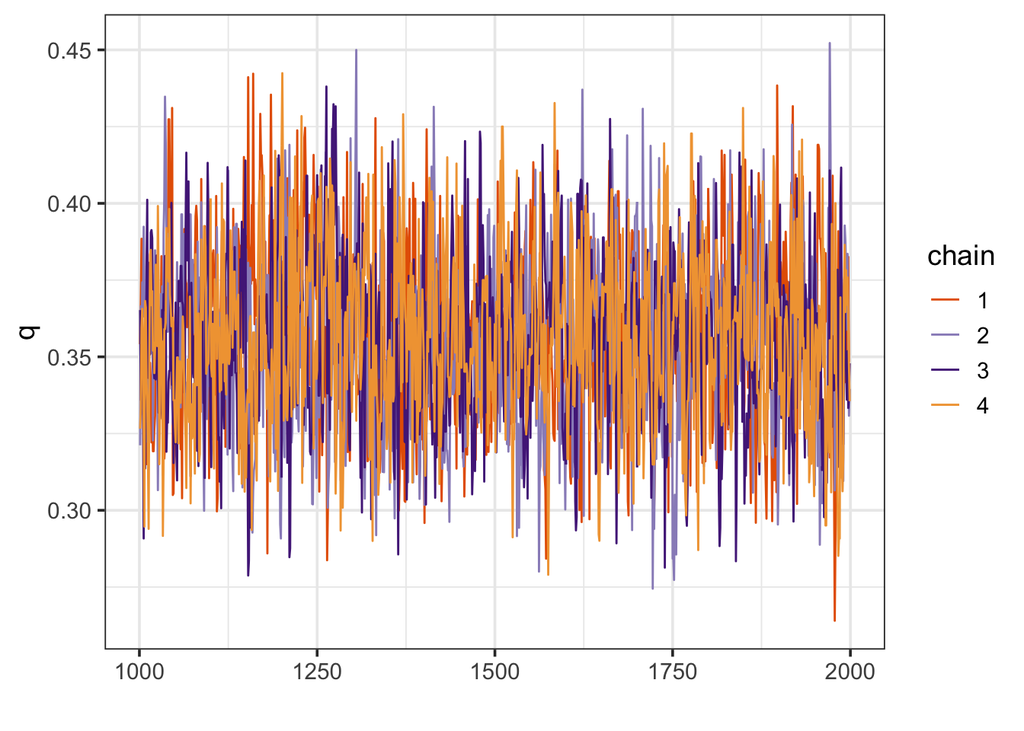

```r
stan_trace(fit, "q") + theme_bw(base_size = 14)
```

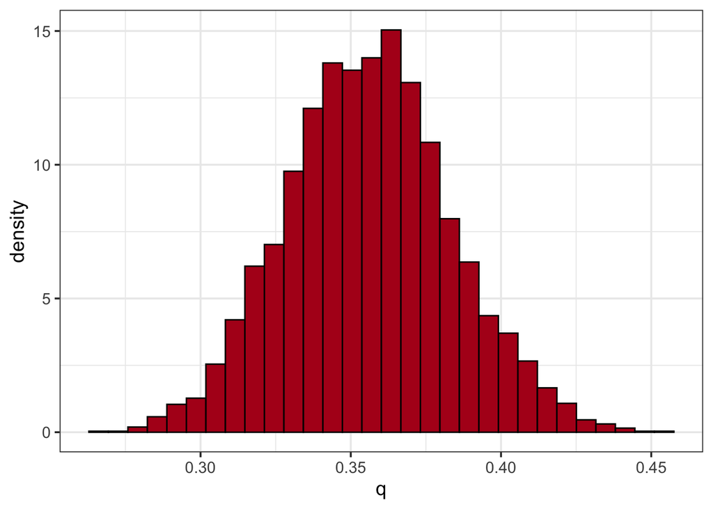

```r
stan_hist(fit, "q") + theme_bw(base_size = 14)
```

```r
waic_est <- loo::waic(extract(fit)$log_lik)$estimates
waic_est
```

```
##               Estimate         SE
## elpd_waic -196.4374346 4.96427130
## p_waic       0.9942043 0.03453522
## waic       392.8748693 9.92854260
```

```r
c(waic_est[2, 1], general_function_var(bern, 1, 1))
```

```
## [1] 0.9942043 0.9977315
```

```r
c(waic_est[3, 1]/(2*length(bern)), WAIC(bern, 1, 1), ba_mean_log_loss(true_dist, bern, 1,1))
```

```
## [1] 0.6547914 0.6548039 0.6534306
```

```r
stan_waic <- function(exp_data){
  tempmodel <- readRDS("191223_01.rds")
  fit <- sampling(tempmodel, data = list(X = exp_data, N = length(exp_data)),
                  seed = 1, refresh = 0, show_messages = F)
  waic_est <- waic(extract(fit)$log_lik)$estimates
  waic_est[3, 1]/(2*length(exp_data))
}
```

```r
stan_waic_res <- lapply(1:100, function(i){
  c(i, stan_waic(rbinom(n = data_length, size = 1, prob = q)))
})
stan_waic_res_df <- stan_waic_res %>% do.call(rbind, .) %>% data.frame() %>% setNames(nm =c("ind", "res"))
```

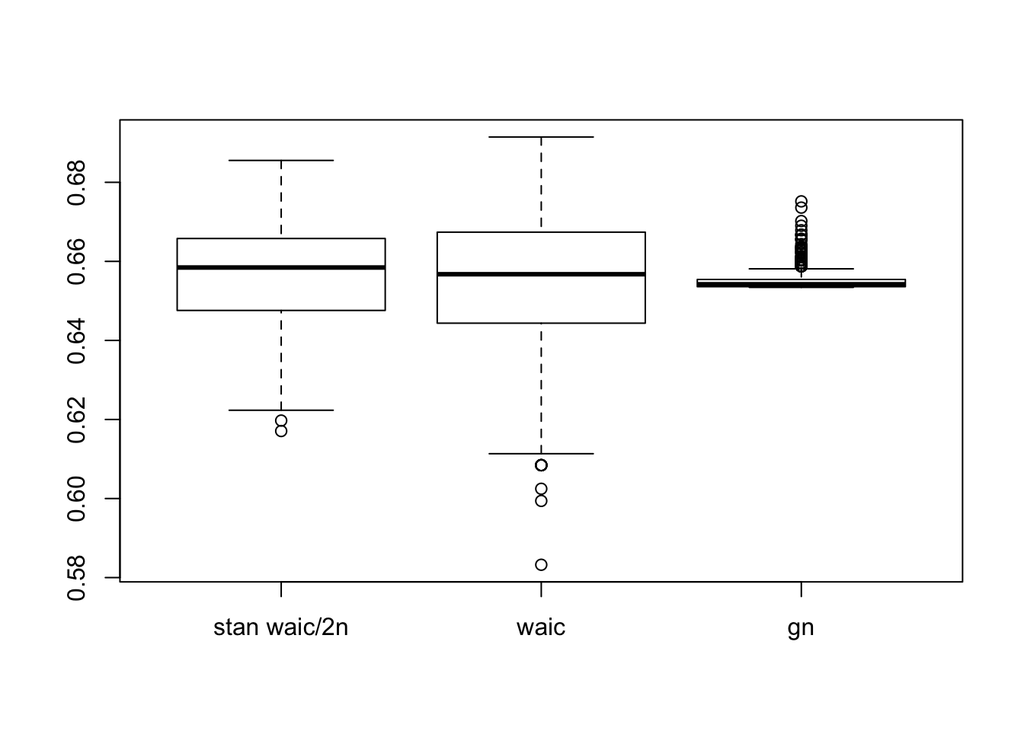

```r
waic_dist     <- replicate(1000, WAIC(rbinom(data_length, 1, q), 1, 1))
gen_loss_dist <- replicate(1000, ba_mean_log_loss(base_dist = true_dist, rbinom(data_length, 1, q), 1, 1))
boxplot(stan_waic_res_df$res, waic_dist, gen_loss_dist, names = c("stan waic/2n", "waic", "gn"))
```

```r
c(mean(stan_waic_res_df$res), mean(waic_dist), mean(gen_loss_dist))
```

```
## [1] 0.6559359 0.6552408 0.6551162
```

### BIC, Free- Energy, WBIC

$p(x^n) = \int{p(X^n|\theta)}\phi(\theta)d\theta$ $p(x^n) = \frac{B(\alpha + \sum_{i}x_{i}, \space \beta + n + \sum_{i}{x_{i}})}{B(\alpha, \space \beta)}$

```r
marginal_lik <- function(exp_data, alpha, beta){
  beta(alpha + sum(exp_data), beta + length(exp_data) - sum(exp_data))/beta(alpha, beta)
}
marginal_lik(bern, 1, 1)
```

```
## [1] 9.121934e-87
```

#### Free Energy

$$F_{n} = - \log{p(X^n)} = \log\int{p(X^n|\theta)\phi(\theta)d\theta}$$
$$E_{X^n}(F_{n})= -n\int{q(x)\log{q(x)}dx} + \int{\log{\frac{q(x^n)}{p(x
^n)}q(x^n)dx^n}}$$

```r
f_energy <- function(exp_data, alpha, beta){
  -log(marginal_lik(exp_data, alpha = alpha, beta = beta))
}
f_energy(bern, 1, 1)
```

```
## [1] 198.1142
```

#### BIC

Bayesian Information Criterion:

$$\mathrm{BIC} = -\sum_{i}{\log{(p_{i}|\hat\theta_{ML})}} + \frac{d}{2}\log{n}$$
For this problem:
$$\mathrm{BIC} = -\sum_{i}{\left[x_{i}\log\bar{x} + (n - x_{i})\log(1-\bar{x}) \right]} + \frac{\log{n}}{2}$$

```r
max_log_lik <- function(exp_data){
  sum(log(ml_pred_dist(exp_data, exp_data)))
}
BIC <- function(exp_data){
    - max_log_lik(exp_data) + (1/2)*log(length(exp_data))
}
BIC(bern)
```

```
## [1] 198.2947
```

#### WBIC

Posterior distribution under condition in which inverse temperature$\beta = 1/\log{n}$
$$L_{n}(\theta) = -\frac{1}{n}\sum_{i}\log{p(x_{i}|\theta)}$$
$$\mathrm{WBIC} = \frac{\int{nL_{n}(\theta){\Pi}_{i}{p(x_{i}|\theta)^\beta\phi(\theta)d\theta}}}{\int{\Pi_{i}{p(x_{i}|\theta)^{\beta}\phi(\theta)d\theta}}}$$

$$WBIC = n\psi\left( \alpha + \beta + \frac{n}{\log{n}} \right) - \left( n - \sum_{i}x_{i} \right)\psi\left( \beta +\frac{n - \sum_{i}{x_{i}}}{\log{n}} \right) - \left( - \sum_{i}{x_{i}} \right)\phi \left( \alpha + \frac{\sum_{i}{x_{i}}}{\log{n}}\right)$$

under $\frac{d}{dz}\log{\Gamma(z)}$

```r
WBIC <- function(exp_data, alpha, beta){
  n <- length(exp_data)
  x <- sum(exp_data)
  n * digamma( alpha + beta + n/log(n)) -
    ( n- x ) * digamma( beta + (n-x)/log(n) ) -
    x * digamma( alpha + x/log(n) )
}
WBIC(bern, alpha, beta)
```

```
## [1] 198.2187
```

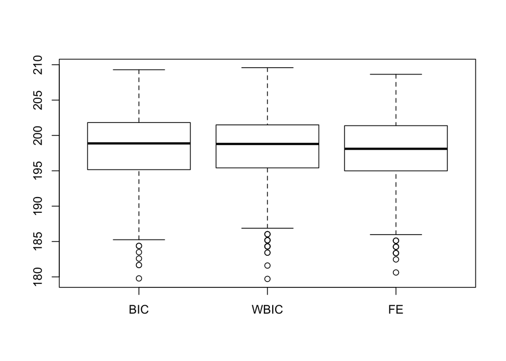

```r
bic_dist <- sapply(1:1000, function(i)BIC(rbinom(data_length, 1, q)))
wbic_dist <- sapply(1:1000, function(i)WBIC(rbinom(data_length, 1, q), alpha = 1, beta = 1))
free_energy_dist <- sapply(1:1000, function(i)f_energy(rbinom(data_length, 1, q), alpha = 1, beta = 1))
boxplot(bic_dist, wbic_dist, free_energy_dist, names = c("BIC", "WBIC", "FE"))
```

```r
c(mean(bic_dist), mean(wbic_dist), mean(free_energy_dist))
```

```
## [1] 198.3326 198.3119 198.0001
```